# Aggregating and Analyzing Data with dplyr

Bracket subsetting is handy, but it can be cumbersome and difficult to read, especially for complicated operations.

Luckily, the [`dplyr`](https://cran.r-project.org/package=dplyr) package provides a number of very useful functions for manipulating data frames in a way that will reduce repetition, reduce the probability of making errors, and probably even save you some typing. As an added bonus, you might even find the `dplyr` grammar easier to read.

1. `select()`
2. `filter()`
3. `group_by()`
4. `summarize()`
5. `mutate()`

Packages in R are sets of additional functions that let you do more stuff in R. The functions we’ve been using, like `str()`, come built into R; packages give you access to more functions. You need to install a package and then load it to be able to use it.

```
install.packages("dplyr") ## install
```

{: .language-r}

You might get asked to choose a CRAN mirror – this is asking you to choose a site to download the package from. The choice doesn’t matter too much; I’d recommend choosing the RStudio mirror.

```
library("dplyr")          ## load
```

{: .language-r}

You only need to install a package once per computer, but you need to load it every time you open a new R session and want to use that package.

## What is dplyr?

The package `dplyr` is a fairly new (2014) package that tries to provide easy tools for the most common data manipulation tasks. It is built to work directly with data frames. The thinking behind it was largely inspired by the package `plyr` which has been in use for some time but suffered from being slow in some cases.`dplyr` addresses this by porting much of the computation to C++. An additional feature is the ability to work with data stored directly in an external database. The benefits of doing this are that the data can be managed natively in a relational database, queries can be conducted on that database, and only the results of the query returned.

This addresses a common problem with R in that all operations are conducted in memory and thus the amount of data you can work with is limited by available memory. The database connections essentially remove that limitation in that you can have a database of many 100s GB, conduct queries on it directly and pull back just what you need for analysis in R.

### Selecting columns and filtering rows

To select columns of a data frame, use `select()`. The first argument to this function is the data frame (`variants`), and the subsequent arguments are the columns to keep.

```
select(variants, sample_id, REF, ALT, DP)
```

{: .language-r}

[output not shown]

{: .output}

To select all columns *except* certain ones, put a “-” in front of the variable to exclude it.

```
select(variants, -CHROM)
```

{: .language-r}

[output not shown]

{: .output}

To choose rows, use `filter()`:

```
filter(variants, sample_id == "SRR2584863")
```

{: .language-r}

[output not shown]

{: .output}

Note that this is equivalent to the base R code below, but is easier to read!

```
variants[variants$sample_id == "SRR2584863",]
```

{: .language-r}

### Pipes

But what if you wanted to select and filter? We can do this with pipes. Pipes, are a fairly recent addition to R. Pipes let you take the output of one function and send it directly to the next, which is useful when you need to many things to the same data set. It was possible to do this before pipes were added to R, but it was much messier and more difficult. Pipes in R look like `%>%` and are made available via the `magrittr` package, which is installed as part of `dplyr`. If you use RStudio, you can type the pipe with `Ctrl` + `Shift` + `M` if you’re using a PC, or `Cmd` + `Shift` + `M` if you’re using a Mac.

```
variants %>%
  filter(sample_id == "SRR2584863") %>%
  select(REF, ALT, DP) %>%
  head()
```

{: .language-r}

```
# A tibble: 6 x 3
  REF      ALT          DP
  <chr>    <chr>     <dbl>
1 T        G             4
2 G        T             6
3 G        T            10
4 CTTTTTTT CTTTTTTTT    12
5 CCGC     CCGCGC       10
6 C        T            10
```

{: .output}

In the above code, we use the pipe to send the `variants` dataset first through `filter()`, to keep rows where `sample_id` matches a particular sample, and then through `select()` to keep only the `REF`, `ALT`, and `DP` columns. Since `%>%` takes the object on its left and passes it as the first argument to the function on its right, we don’t need to explicitly include the data frame as an argument to the `filter()` and `select()` functions any more. We then pipe the results to the `head()` function so that we only see the first six rows of data.

Some may find it helpful to read the pipe like the word “then”. For instance, in the above example, we took the data frame `variants`, *then* we `filter`ed for rows where `sample_id` was SRR2584863, *then* we `select`ed the `REF`, `ALT`, and `DP` columns, *then* we showed only the first six rows. The **`dplyr`** functions by themselves are somewhat simple, but by combining them into linear workflows with the pipe, we can accomplish more complex manipulations of data frames.

If we want to create a new object with this smaller version of the data we can do so by assigning it a new name:

```
SRR2584863_variants <- variants %>%
  filter(sample_id == "SRR2584863") %>%
  select(REF, ALT, DP)
```

{: .language-r}

This new object includes all of the data from this sample. Let’s look at just the first six rows to confirm it’s what we want:

```
SRR2584863_variants %>% head()
```

{: .language-r}

```
# A tibble: 6 x 3
  REF      ALT          DP
  <chr>    <chr>     <dbl>
1 T        G             4
2 G        T             6
3 G        T            10
4 CTTTTTTT CTTTTTTTT    12
5 CCGC     CCGCGC       10
6 C        T            10
```

{: .output} We can also look at the first six rows using tidyverse function `slice()`:

```
SRR2584863_variants %>% slice(1:6)
```

{: .language-r}

```
# A tibble: 6 x 3
  REF      ALT          DP
  <chr>    <chr>     <dbl>
1 T        G             4
2 G        T             6
3 G        T            10
4 CTTTTTTT CTTTTTTTT    12
5 CCGC     CCGCGC       10
6 C        T            10
```

{: .output}

## Exercise: Pipe and filter

> Starting with the `variants` dataframe, use pipes to subset the data to include only observations from SRR2584863 sample, where the filtered depth (DP) is at least 10. Retain only the columns `REF`, `ALT`, and `POS`.

## Solution

> > ```
> >  variants %>%
> >  filter(sample_id == "SRR2584863" & DP >= 10) %>%
> >  select(REF, ALT, POS)
> > ```

> > {: .language-r}

> > ```
> > # A tibble: 16 x 3
> >    REF      ALT           POS
> >    <chr>    <chr>       <dbl>
> >  1 G        T          281923
> >  2 CTTTTTTT CTTTTTTTT  433359
> >  3 CCGC     CCGCGC     473901
> >  4 C        T          648692
> >  5 G        A         1733343
> >  6 A        C         2446984
> >  7 G        T         2618472
> >  8 A        T         2665639
> >  9 G        A         2999330
> > 10 A        C         3339313
> > 11 C        A         3401754
> > 12 A        C         3488669
> > 13 G        T         3909807
> > 14 A        G         4100183
> > 15 A        C         4201958
> > 16 TGG      T         4431393
> > ```

> > {: .output} {: .solution} {: .challenge}

### Mutate

Frequently you’ll want to create new columns based on the values in existing columns, for example to do unit conversions or find the ratio of values in two columns. For this we’ll use the `dplyr` function `mutate()`.

We have a column titled “QUAL”. This is a Phred-scaled confidence score that a polymorphism exists at this position given the sequencing data. Lower QUAL scores indicate low probability of a polymorphism existing at that site. We can convert the confidence value QUAL to a probability value according to the formula:

Probability = 1- 10 ^ -(QUAL/10)

Let’s add a column (`POLPROB`) to our `variants` dataframe that shows the probability of a polymorphism at that site given the data. We’ll show only the first six rows of data.

```
variants %>%
  mutate(POLPROB = 1 - (10 ^ -(QUAL/10))) %>%
  slice(1:6)
```

{: .language-r}

```
# A tibble: 6 x 30
  sample_id CHROM    POS ID    REF   ALT    QUAL FILTER INDEL   IDV   IMF    DP
  <chr>     <chr>  <dbl> <lgl> <chr> <chr> <dbl> <lgl>  <lgl> <dbl> <dbl> <dbl>
1 SRR25848… CP00…   9972 NA    T     G        91 NA     FALSE    NA  NA       4
2 SRR25848… CP00… 263235 NA    G     T        85 NA     FALSE    NA  NA       6
3 SRR25848… CP00… 281923 NA    G     T       217 NA     FALSE    NA  NA      10
4 SRR25848… CP00… 433359 NA    CTTT… CTTT…    64 NA     TRUE     12   1      12
5 SRR25848… CP00… 473901 NA    CCGC  CCGC…   228 NA     TRUE      9   0.9    10
6 SRR25848… CP00… 648692 NA    C     T       210 NA     FALSE    NA  NA      10
# … with 18 more variables: VDB <dbl>, RPB <dbl>, MQB <dbl>, BQB <dbl>,
#   MQSB <dbl>, SGB <dbl>, MQ0F <dbl>, ICB <lgl>, HOB <lgl>, AC <dbl>,
#   AN <dbl>, DP4 <chr>, MQ <dbl>, Indiv <chr>, gt_PL <dbl>, gt_GT <dbl>,
#   gt_GT_alleles <chr>, POLPROB <dbl>
```

{: .output}

## Exercise

> There are a lot of columns in our dataset, so let’s just look at the `sample_id`, `POS`, `QUAL`, and `POLPROB` columns for now. Add a line to the above code to only show those columns.

## Solution

> > ```
> > variants %>%
> >  mutate(POLPROB = 1 - 10 ^ -(QUAL/10)) %>%
> >  glimpse %>%
> >  select(sample_id, POS, QUAL, POLPROB)
> > ```

> > {: .language-r}

> > ```
> > Rows: 801
> > Columns: 30
> > $ sample_id     <chr> "SRR2584863", "SRR2584863", "SRR2584863", "SRR2584863",…
> > $ CHROM         <chr> "CP000819.1", "CP000819.1", "CP000819.1", "CP000819.1",…
> > $ POS           <dbl> 9972, 263235, 281923, 433359, 473901, 648692, 1331794, …
> > $ ID            <lgl> NA, NA, NA, NA, NA, NA, NA, NA, NA, NA, NA, NA, NA, NA,…
> > $ REF           <chr> "T", "G", "G", "CTTTTTTT", "CCGC", "C", "C", "G", "ACAG…
> > $ ALT           <chr> "G", "T", "T", "CTTTTTTTT", "CCGCGC", "T", "A", "A", "A…
> > $ QUAL          <dbl> 91.0000, 85.0000, 217.0000, 64.0000, 228.0000, 210.0000…
> > $ FILTER        <lgl> NA, NA, NA, NA, NA, NA, NA, NA, NA, NA, NA, NA, NA, NA,…
> > $ INDEL         <lgl> FALSE, FALSE, FALSE, TRUE, TRUE, FALSE, FALSE, FALSE, T…
> > $ IDV           <dbl> NA, NA, NA, 12, 9, NA, NA, NA, 2, 7, NA, NA, NA, NA, NA…
> > $ IMF           <dbl> NA, NA, NA, 1.000000, 0.900000, NA, NA, NA, 0.666667, 1…
> > $ DP            <dbl> 4, 6, 10, 12, 10, 10, 8, 11, 3, 7, 9, 20, 12, 19, 15, 1…
> > $ VDB           <dbl> 0.0257451, 0.0961330, 0.7740830, 0.4777040, 0.6595050, …
> > ```
> >
> > [output cut: 17 more lines]

> > {: .output}

> > ```
> > # A tibble: 801 x 4
> >    sample_id      POS  QUAL POLPROB
> >    <chr>        <dbl> <dbl>   <dbl>
> >  1 SRR2584863    9972    91    1.00
> >  2 SRR2584863  263235    85    1.00
> >  3 SRR2584863  281923   217    1
> >  4 SRR2584863  433359    64    1.00
> >  5 SRR2584863  473901   228    1
> >  6 SRR2584863  648692   210    1
> >  7 SRR2584863 1331794   178    1
> >  8 SRR2584863 1733343   225    1
> >  9 SRR2584863 2103887    56    1.00
> > 10 SRR2584863 2333538   167    1
> > # … with 791 more rows
> > ```

> > {: .output} {: .solution} {: .challenge}

### Split-apply-combine data analysis and the summarize() function

Many data analysis tasks can be approached using the “split-apply-combine” paradigm: split the data into groups, apply some analysis to each group, and then combine the results. `dplyr` makes this very easy through the use of the `group_by()` function, which splits the data into groups. When the data is grouped in this way `summarize()` can be used to collapse each group into a single-row summary. `summarize()` does this by applying an aggregating or summary function to each group. For example, if we wanted to group by sample_id and find the number of rows of data for each sample, we would do:

```
variants %>%
  group_by(sample_id) %>%
  summarize(n())
```

{: .language-r}

```
# A tibble: 3 x 2
  sample_id  `n()`
  <chr>      <int>
1 SRR2584863    25
2 SRR2584866   766
3 SRR2589044    10
```

{: .output}

It can be a bit tricky at first, but we can imagine physically splitting the data frame by groups and applying a certain function to summarize the data.

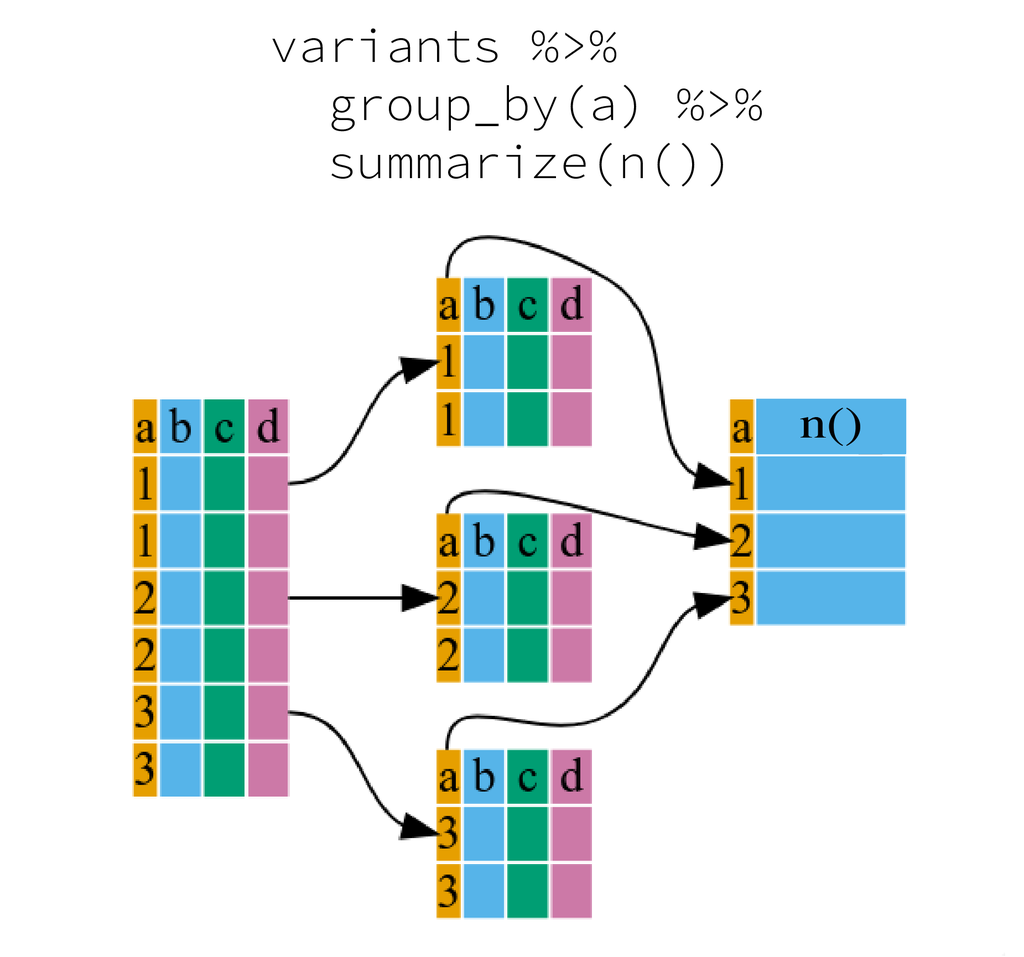

[^1]

Here the summary function used was `n()` to find the count for each group. Since this is a quite a common operation, there is a simpler method called `tally()`:

```
variants %>%
  group_by(sample_id) %>%
  tally()
```

{: .language-r}

```
# A tibble: 3 x 2
  sample_id      n
  <chr>      <int>
1 SRR2584863    25
2 SRR2584866   766
3 SRR2589044    10
```

{: .output}

We can also apply many other functions to individual columns to get other summary statistics. For example,we can use built-in functions like `mean()`, `median()`, `min()`, and `max()`. These are called “built-in functions” because they come with R and don’t require that you install any additional packages. By default, all **R functions operating on vectors that contains missing data will return NA**. It’s a way to make sure that users know they have missing data, and make a conscious decision on how to deal with it. When dealing with simple statistics like the mean, the easiest way to ignore `NA` (the missing data) is to use `na.rm = TRUE` (`rm` stands for remove).

So to view the highest filtered depth (`DP`) for each sample:

```
variants %>%
  group_by(sample_id) %>%
  summarize(max(DP))
```

{: .language-r}

```
# A tibble: 3 x 2
  sample_id  `max(DP)`
  <chr>          <dbl>
1 SRR2584863        20
2 SRR2584866        79
3 SRR2589044        16
```

{: .output}

[Handy dplyr cheatsheet](https://github.com/rstudio/cheatsheets/raw/master/data-transformation.pdf)

[^2]

[^1]: This figure was adapted from the Software Carpentry lesson, [R for Reproducible Scientific Analysis](https://swcarpentry.github.io/r-novice-gapminder/13-dplyr/)
[^2]: Much of this lesson was copied or adapted from Jeff Hollister’s [materials](http://usepa.github.io/introR/2015/01/14/03-Clean/)